# Implementation Notes

exDE

Sean L. Wu, John M. Henry, David Smith

2022-04-26

Library $\uparrow$ Hub | Computation

## Variables

### -

- **Abiotic** sets up exogenous variables describing weather and hydrology, including rainfall, temperature, and relative humidity
- **Shock** handles major routines that cause major changes to systems, such as COVID-19
- **Control** handles distribution or application of medical interventions (drugs, vaccines, monoclonal antibodies) and vector control
- **Behavior** handles changing human and mosquito behaviors
- **Resources** handles changing availability of resources
- **MozyEcology**

### Abiotic

#### -

From `abiotic.R`

```r
Abiotic.forced <- function(t, pars) {
  pars = Weather(t, pars)
  pars = Hydrology(t, pars)
  return(pars)
}
```

#### Weather

Functions that are called by `Weather` should set the values of exogenous variables that get used later.

#### Hydrology

Functions that are called by `Hydrology` should set the values of variables that could affect the availability of habitats. A model could define *endogenous* variables that are a function of rainfall and temperature, so it is called after `Weather.`

If a hydrological model is being used to simulate habitat dynamics, the model must clearly define variables that match the features of the habitats.

- Some of these variables might affect *habitat search weights* and egg laying;
- Some of these variables will be used in functions called by `LBionomics` to set `baseline` parameter values.

### Control

#### -

- *MassMedical*
- *EnhancedClinical*
- *VectorControl*

#### EnhancedClinical

#### Vector Control

- Mass Bednet Distributions
- Mass Spraying, including IRS and areal spraying
- Distribute Sugar Baits
- Distribute Ovitraps
- Zooprophylaxis

### Behavior

#### -

- *CareSeeking*
- *PersonalProtect*
- *HumanMobility*
- *MozySearch*

#### CareSeeking

#### PersonalProtect

#### HumanMobility

#### MozySearch

### Resources

#### -

- Visitors
- OtherBlood
- Sugar

#### Visitors

#### OtherBlood

#### Sugar

#### Internals

### MozyEcology

## Forcing

### -

The way parameter values are computed is flexible and can be configured at setup to allow exogenous forcing by variables describing weather (${\cal W}(t)$), vector control coverage (${\cal V}(t)$), and variables describing resource availability. Library elements in `exDE` thus encode model families, or (depending on whether you lump or split model taxonomies) perhaps *super-families.*

The following sections describe how the code was designed to modularize forcing.

### Code

Functions that compute derivatives in `exDE` should be easy to read. The functions that compute derivatives should look like the math on a page. For example, one version of the Ross-Macdonald model looks like this:

$$\begin{eqnarray}
\frac{\textstyle{dM}}{\textstyle{dt}} &=& \Lambda - \Omega \cdot
M \\
\frac{\textstyle{dY}}{\textstyle{dt}} &=& fq\kappa (M - Y) -
\Omega \cdot Y \\
\frac{\textstyle{dZ}}{\textstyle{dt}} &=& \Upsilon \cdot
f_{\tau^{-1}} q_{\tau^{-1}}\kappa_{\tau^{-1}} (M_{\tau^{-1}} -
Y_{\tau^{-1}}) - \Omega \cdot Z \\
\end{eqnarray}$$

To encode it, the terms and parameters in the model use the same names: terms are passed (*e.g.*, `Lambda` and `kappa`); and parameters are computed and attached by name to `MYZpar$now` (*e.g.* `MYZpar$now$f` and `MYZpar$now$Omega`) so that the code is easy to read:

```r
with(MYZpar$now,{
  dMdt <- Lambda - Omega %*% M
  dYdt <- f*q*kappa*(M - Y) - Omega %*% Y
  dZdt <- Upsilon %*% (fqkappa_eip * (M_eip - Y_eip)) - Omega %*% Z
})
```

Note that the term `fqkappa_eip` is $f_{\tau^{-1}} q_{\tau^{-1}}\kappa_{\tau^{-1}}$, computed by internalizing the lag term.

### Effect Sizes

#### -

To implement forcing by exogenous parameters, we have developed a generalized way of computing the parameter values in two stages:

#### Pseudo-code

- compute `baseline`
- clone: `baseline` $\rightarrow$ `now`
- effect sizes:
  - use `baseline` to compute `EfSz`
  - modify `now` using `EfSz`
- Use `now` in `dMYZdt` or `dLdt`

### Setup

#### -

We adopt the convention of setting up models by configuring a function that calls the baseline parameter:

```r
baseline$x = F_x(t, pars)
```

The function `F_x` is an `S3` class:

```r
F_x = function(t, pars){
  UseMethod("F_x", pars$Xmod$Fx_pars)
}
```

A default option assigns a static value for each parameter:

```r
F_x.0 = function(t, pars){
  pars$Xmod$Fx_pars$x0
}
```

which gets setup with a default value for `x0` that can be overwritten:

```r
setup_Fx_default = function(pars, x0 = 1){
  Fx_pars = list()
  class(Fx_pars) <- "0"
  Fx_pars$x0 =  x0
  pars$Xmod$Fx_pars = Fx_pars
  return(pars)
}
```

The model library expands by adding new functions that *force* parameters

Alternatives models are added by adding the function:

```r
F_x.alt = function(t, pars){with(pars$Xmod$Fx_pars,{
  (a*t)^b
})}
```

And writing code to set it up:

```r
setup_Fx_alt = function(pars, a=1, b=2){
  Fx_pars = list()
  class(Fx_pars) <- "alt"
  Fx_pars$a = a
  Fx_pars$b = b
  pars$Xmod$Fx_pars = Fx_pars
  return(pars)
}
```

Calling `setup_Fx_alt(pars)` overwrites a previous version of `pars$Xmod$Fx_pars` and thus created a new model, derived from another one.

#### example

**NOTE** The following example follows the logic for the parameter $f$, but the same protocols are used for other parameters in the models $\cal MYZ$ and $\cal L$

In the translation to code, the parameter $f$ is stored as `MZpar$now$f` and flexibility is implemented through dispatching on the function that computes the baseline `F_f`:

```r
MYZpar$baseline$f = MYZpar$now$f = F_f(t, pars)
```

Modularity is implemented by using `MYZpar$baseline` in functions that compute independent effect sizes for vector control, but using those effect sizes to modify `MYZpar$now`

Models with the same *state space* but different ways of setting parameters can thus be encoded through dispatching on `F_f`

For example, if the *baseline* parameters were static, then we would use the function:

```r
F_f.0 = function(t, pars){
  MYZpars$f0
}
```

but we might also choose to let $f$ be forced as a sigmoidal function of air temperature:

```r
F_f.temp1 = function(t, pars){
  with(pars,
       f_max*a_ft*Temperature^2/(b_ft+a_ft*Temperature^2)
}
```

### EIP

#### -

The EIP can be forced by temperature. In `exDE,` we have adopted the convention that algorithms should compute and store the EIP for mosquitoes at the moment they become *infectious* as `MYZpar$now$eip`

One to define the EIP for *P. falciparum* infecting mosquitoes is at the moment they become infected, $\tau(t)$ – the mosquito would become infectious at time
$$t+\tau(t) \models Y(t)
\left[\rightarrow Z\left(t+\tau\left(t\right)\right)
\right].$$

In DDEs, we need to know the EIP for mosquitoes when they become infectious. In *Spatial Dynamics of Malaria Transmission [1],* we called this quantity $\tau^{-1}(t)$ – a mosquito that became infectious at time $t$ was infected at time $t-\tau^{-1}(t)$:

$$t-\tau^{-1}(t) \models
Z(t)\; \left[\leftarrow
Y\left(t-\tau^{-1}\left(t\right)\right)\right].$$

#### Notes

We let $\tau(t)$ denote the EIP for a cohort of mosquitoes that becomes infected at time $t$; such that they will become infectious at time $t+\tau(t)$.

In DDEs, we need to know the EIP for the cohort of mosquitoes that becomes infectious at time $t$, denoted $\tau^{-1}(t)$ denote the EIP for a cohort of mosquitoes that became infectious at time $t$.

Suppose for example that temperature varies annually and that it affects the EIP. We can construct $\tau$ using a $\sin$ function:

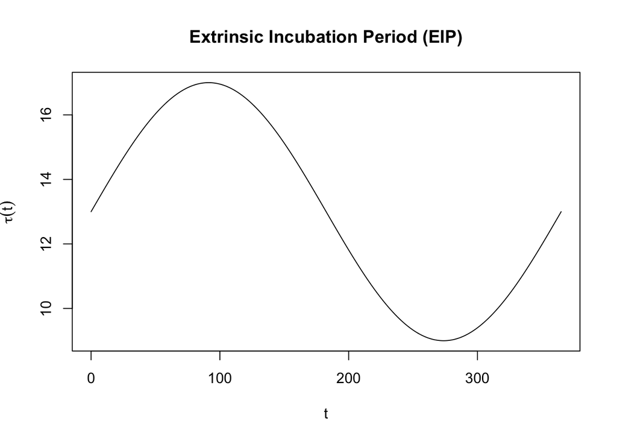

Taking advantage of the fact that the inverse is just a reflection across the $y=x$ line, we can plot $t+\tau(t)$ the answer (in blue):

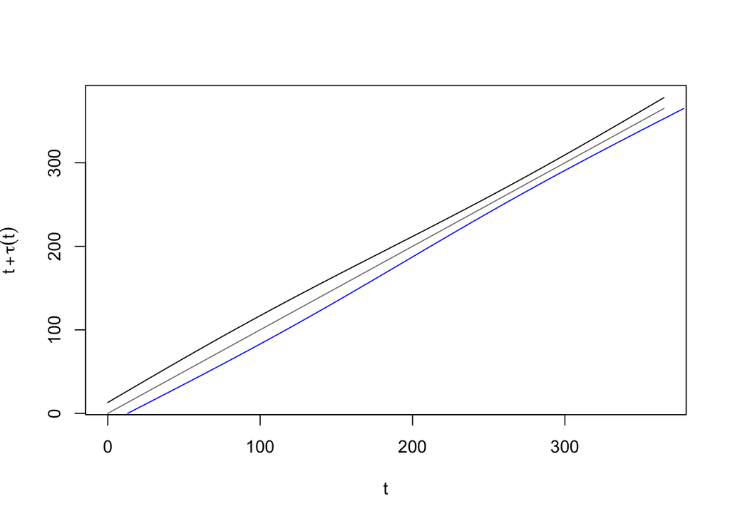

…but it is difficult to compute the inverse. We can compute the inverse of $\tau(t)$ easily enough, but it is the inverse of $t+\tau(t)$ that we need:

So even in this simple case, we would have to do the calculations numerically.

## Models

## Refs

1.

Wu SL, Henry JM, Citron DT, Ssebuliba DM, Nsumba JN, C HMS, et al. Spatial dynamics of malaria transmission. PLOS Computational Biology. 2023;19: e1010684. doi:10.1371/journal.pcbi.1010684